# WhatsApp analysis

# load the whatsapp text file and create the Corpus object

```r
texts <- readLines("whatsapp.txt")
texts2 <- readLines("whatsapp.txt")

#create the corpus using tm
docs <- Corpus(VectorSource(texts))

docs[[2]]$content # double brackets to get metadata on second tweet; $content (or single brackets)
```

# Apply common preporocessing functions

```r
## see how it's cleaned up one of the stories
clean_corp[[250]]$content
```

```
[1] "  really hope irex will pay back"
```

## create TermDocumentMatrix (TDM) or DocumentTermMatrix (DTM) to get frequency matrices of corpus

```r
dim(qual_tdm2)
```

```
[1]     0 13409
```

# calculate total frequency of terms and sort in decreasing order

```r
head(freqTerms)
```

```
 just   get going   can  home  good
  740   684   579   485   467   454
```

# create bar chart, reorder and labelling

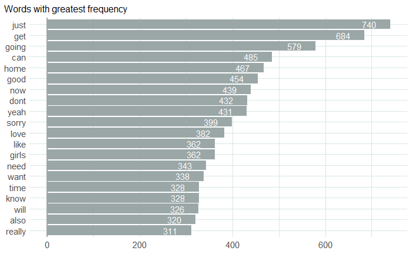

```r
ggplot(freqTermsdf[1:20,], aes(x = reorder(terms,number), y=number)) + geom_bar(stat = "identity", fill = "#9ba7a7") +
  geom_text(aes(label = number),size = 4, hjust = 2, color = "white") + coord_flip() +
  labs(title = "Words with greatest frequency", x = "Number of mentions", y = "terms") +
  geom_hline(yintercept = 0, size =1, colour = "#9ba7a7") +
  coord_flip() + theme_minimal() +
  theme(axis.title.y = element_blank(),
        plot.title = element_text(size = 12, hjust = -.1),
        axis.title.x = element_blank(),
        axis.ticks.x = element_blank(),
        axis.ticks.y = element_blank(),
        axis.text.x = element_text(size = 11),
        axis.text.y = element_text(size = 11)) +
  theme(panel.grid.major = element_line(color = "#d8e6e6" ),
        panel.grid.minor = element_line("#d8e6e6")) +
  labs(title = "Words with greatest frequency", x = "Number of mentions", y = "terms")
```

I’m happy to see that “love” shows up at #11! Even after 10 years of marriage, we still say “love you”. I’d like to see this go up in the future though. It’s interesting that “sorry” comes up at about the same frequency. I think a good dose of apologies or admitting that one messed up is part of a healthy relationship so the two words are not necessarily in conflict. I’m guessing I say “sorry” more just because I’m the one that tends to forget things. I will look into that later.  
Much of our communication is about logistics such as when I’ll be leaving work, where I’m going, or when I expect to get home so I’m not surprised to words like “get”, “home”, “now”, or “going” in the top 10. The word “girls” refers to our two daughters.

## Simple word cloud

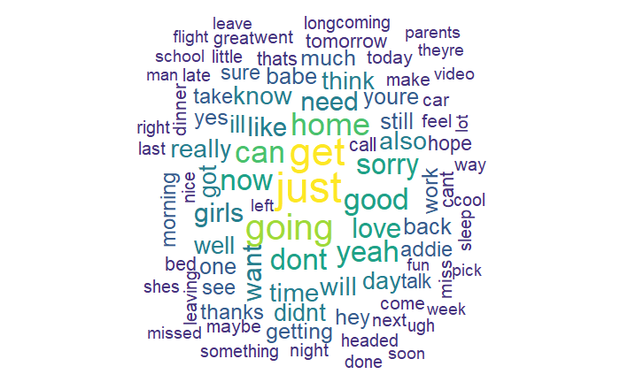

# compare number of messages by author

```r
#Use rwa_read function from rwhatsapp package to convert text to dataframe format
texts2 <- rwa_read("whatsapp.txt")

texts2 %>% na.omit() %>% group_by(author) %>% summarize(number = n())


num_texts <- texts2 %>% na.omit() %>% tabyl(author) %>%
  adorn_pct_formatting(digits = 0)

kable(num_texts)

library(ggalt)
num_texts %>%
  ggplot(aes(x = author, y = n)) +
  geom_lollipop(point.size = 5) +
  coord_flip() +
  theme_minimal() +
  theme(axis.title.y = element_blank(),
        plot.title = element_text(size = 12, hjust = -.1),
        axis.title.x = element_blank(),
        axis.ticks.x = element_blank(),
        axis.ticks.y = element_blank(),
        axis.text.x = element_text(size = 11),
        axis.text.y = element_text(size = 11)) +
  theme(panel.grid.major = element_line(color = "#d8e6e6" ),
        panel.grid.minor = element_line("#d8e6e6")) +
  labs(title = "Comparison of number of texts sent by Hannah versus Charles in the last 2 years")

# percentage more messages sent by Hannah
(8178-5142)/(8178+5142)
```

[output not shown]